# ggRandomForests: Regression randomForest

John Ehrlinger

Microsoft  
jehrling@microsoft.com

June 14, 2016

# Abtract

Random Forests (Breiman 2001) (RF) are a non-parametric statistical method requiring no distributional assumptions on covariate relation to the response. RF are a robust, nonlinear technique that optimizes predictive accuracy by fitting an ensemble of trees to stabilize model estimates. The **randomForest** package(Liaw and Wiener 2002) is the reference implementation of Breiman’s random forests for regression and classification problems.

Predictive accuracy make RF an attractive alternative to parametric models, though complexity and interpretability of the forest hinder wider application of the method. We introduce the **ggRandomForests** package, tools for visually understand random forest models grown in **R** (R Core Team 2014) with the **randomForest** package. The **ggRandomForests** package is structured to extract intermediate data objects from **randomForest** objects and generates figures using the **ggplot2** (Wickham 2009) graphics package.

This document is structured as a tutorial for building random forests for regression with the **randomForest** package and using the **ggRandomForests** package for investigating how the forest is constructed. We investigate the Boston Housing data (Harrison and Rubinfeld 1978 Belsley, Kuh, and Welsch (1980)). We demonstrate random forest variable selection using Variable Importance (VIMP) (Breiman 2001). We will also demonstrate the use of variable dependence plots (Friedman 2000) to aid interpretation RF results. We then examine variable interactions between covariates using conditional variable dependence plots. The goal of the exercise is to demonstrate the strength of using Random Forest methods for both prediction and information retrieval in regression settings.

**keywords:** random forest, regression, VIMP, minimal depth, **R**, **randomForest**

# About this document

This document is a package vignette for the **ggRandomForests** package for “Visually Exploring Random Forests” (http://CRAN.R-project.org/package=ggRandomForests). The **ggRandomForests** package is designed for use with the **randomForest** package (http://CRAN.R-project.org/package=randomForest)(Liaw and Wiener 2002) or the **randomForestSRC** package (http://CRAN.R-project.org/package=randomForestSRC)(Ishwaran and Kogalur 2014) for growing random forests for survival (time to event response), regression (continuous response) and classification (categorical response) the settings and uses the **ggplot2** package (http://CRAN.R-project.org/package=ggplot2) (Wickham 2009) for plotting diagnostic and variable association results. **ggRandomForests** is structured to extract data objects from **randomForestSRC** or **randomForest** objects and provides functions for printing and plotting these objects.

The vignette is a tutorial for using the **ggRandomForests** package with the **randomForest** package for building and post-processing random forests for regression settings. In this tutorial, we explore a random forest for regression model constructed for the Boston housing data set (Harrison and Rubinfeld 1978, Belsley, Kuh, and Welsch (1980)), available in the **MASS** package (Venables and Ripley 2002). We grow a random forest and demonstrate how **ggRandomForests** can be used when determining how the response depends on predictive variables within the model. The tutorial demonstrates the design and usage of many of **ggRandomForests** functions and features and also how to modify and customize the resulting **ggplot** graphic objects along the way.

The vignette is written in markdown using the **rmarkdown** package (http://CRAN.R-project.org/package=rmarkdown) (Allaire et al. 2016) and the **knitr** package (http://CRAN.R-project.org/package=knitr) (Xie 2015, Xie (2014), Xie (2013)), which facilitates weaving **R** (R Core Team 2014) code, results and figures into document text. Throughout this document, **R** code will be displayed in **code blocks** as shown below. This code block loads the **R** packages required to run the source code listed in code blocks throughout the remainder of this document.

```r
> library("ggplot2")       # Graphics engine
> library("RColorBrewer")    # Nice color palettes
> library("plot3D")          # for 3d surfaces.
> library("dplyr")           # Better data manipulations
> library("tidyr")           # gather variables into long format
> library("parallel")        # mclapply for multicore processing
>
> # Analysis packages.
> library("randomForest")    # random forests
> library("ggRandomForests") # ggplot2 random forest figures (This!)
> theme_set(theme_bw())     # A ggplot2 theme with white background
```

A development version of the **ggRandomForests** package is available on GitHub (https://github.com). We invite comments, feature requests and bug reports for this package at (https://github.com/ehrlinger/ggRandomForests).

# Introduction

Random Forests (Breiman 2001) (RF) are a fully non-parametric statistical method which requires no distributional or functional assumptions on covariate relation to the response. RF is a robust, nonlinear technique that optimizes predictive accuracy by fitting an ensemble of trees to stabilize model estimates. The **randomForest** package (Liaw and Wiener 2002) is the reference version of Breiman’s random forests for regression (continuous response) and classification (categorical response) problems.

Predictive accuracy make RF an attractive alternative to parametric models, though complexity and interpretability of the forest hinder wider application of the method. We introduce the **ggRandomForests** package for visually exploring random forest models. The **ggRandomForests** package is structured to extract intermediate data objects from **randomForest** objects and generate figures using the **ggplot2** graphics package (Wickham 2009).

Many of the figures created by the **ggRandomForests** package are also available directly from within the **randomForest** package. However **ggRandomForests** offers the following advantages:

- Separation of data and figures: **ggRandomForests** contains functions that operate on either the `randomForest` forest object directly, or on the output from **randomForest** post processing functions to generate intermediate **ggRandomForests** data objects. functions are provide to further process these objects and plot results using the **ggplot2** graphics package. Alternatively, users can use these data objects for their own custom plotting or analysis operations.
- Each data object/figure is a single, self contained object. This allows simple modification and manipulation of the data or **ggplot2** objects to meet users specific needs and requirements.
- The use of **ggplot2** for plotting. We chose to use the **ggplot2** package for our figures to allow users flexibility in modifying the figures to their liking. Each plot function returns either a single `ggplot` object, or a `list` of `ggplot` objects, allowing users to use additional **ggplot2** functions or themes to modify and customize the figures to their liking.

This document is formatted as a tutorial for using the **randomForest** package for building and post-processing random forest models with the **ggRandomForests** package for investigating how the forest is constructed. In this tutorial, we use the Boston Housing Data, available in the **MASS** package (Venables and Ripley 2002), to build a random forest for regression and demonstrate the tools in the **ggRandomForests** package for examining the forest construction.

Random forests are not parsimonious, but use all variables available in the construction of a response predictor. We demonstrate a random forest variable selection process using the Variable Importance measure (VIMP) (Breiman 2001) to assess the impact of variables on forest prediction.

# Data: Boston Housing Values

```r
> # Load the Boston Housing data
> data(Boston, package="MASS")
>
> # Set modes correctly. For binary variables: transform to logical
> Boston$chas <- as.logical(Boston$chas)
```

housing data dictionary.

| Variable | Description | type |
| --- | --- | --- |
| crim | Crime rate by town. | numeric |
| zn | Proportion of residential land zoned for lots over 25,000 sq.ft. | numeric |
| indus | Proportion of non-retail business acres per town. | numeric |
| chas | Charles River (tract bounds river). | logical |
| nox | Nitrogen oxides concentration (10 ppm). | numeric |
| rm | Number of rooms per dwelling. | numeric |
| age | Proportion of units built prior to 1940. | numeric |
| dis | Distances to Boston employment center. | numeric |
| rad | Accessibility to highways. | integer |
| tax | Property tax rate per $10,000. | numeric |
| ptratio | Pupil teacher ratio by town. | numeric |
| black | Proportion of blacks by town. | numeric |
| lstat | Lower status of the population (percent). | numeric |
| medv | Median value of homes ($1000s). | numeric |

The main objective of the Boston Housing data is to investigate variables associated with predicting the median value of homes (continuous `medv` response) within 506 suburban areas of Boston.

# Exploratory Data Analysis

It is good practice to view your data before beginning an analysis, what (Tukey 1977) refers to as Exploratory Data Analysis (EDA). To facilitate this, we use **ggplot2** figures with the `ggplot2::facet_wrap` command to create two sets of panel plots, one for categorical variables with boxplots at each level, and one of scatter plots for continuous variables. Each variable is plotted along a selected continuous variable on the X-axis. These figures help to find outliers, missing values and other data anomalies in each variable before getting deep into the analysis. We have also created a separate **shiny** app (http://shiny.rstudio.com) (Chang et al. 2015), available at (https://ehrlinger.shinyapps.io/xportEDA), for creating similar figures with an arbitrary data set, to make the EDA process easier for users.

The Boston housing data consists almost entirely of continuous variables, with the exception of the “Charles river” logical variable. A simple EDA visualization to use for this data is a single panel plot of the continuous variables, with observation points colored by the logical variable. Missing values in our continuous variable plots are indicated by the rug marks along the x-axis, of which there are none in this data. We used the Boston housing response variable, the median value of homes (`medv`), for X variable.

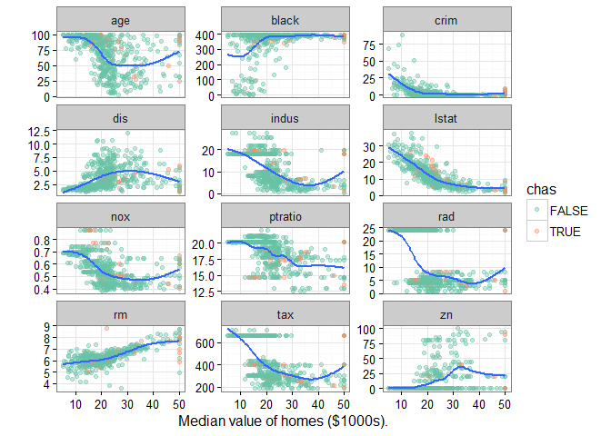

**Figure 1** EDA variable plots. Points indicate variable value against the median home value variable. Points are colored according to the chas variable.

```r
> # Use tidyr::gather to transform the data into long format.
> dta <- gather(Boston, variable, value, -medv, -chas)
>
> # plot panels for each covariate colored by the logical chas variable.
> ggplot(dta)+
+   geom_point(alpha=0.4, aes(x=medv, y=value, color=chas))+
+   geom_smooth(aes(x=medv, y=value), se=FALSE)+
+   labs(y="", x=st.labs["medv"]) +
+   scale_color_brewer(palette="Set2")+
+   facet_wrap(~variable, scales="free_y", ncol=3)
```

This figure is loosely related to a pairs scatter plot (Becker, Chambers, and Wilks 1988), but in this case we only examine the relation between the response variable against the remainder. Plotting the data against the response also gives us a “sanity check” when viewing our model results. It’s pretty obvious from this figure that we should find a strong relation between median home values and the `lstat` and `rm` variables.

# Random Forest - Regression

A Random Forest is grown by *bagging* (L Breiman 1996a) a collection of *classification and regression trees* (CART) (Breiman et al. 1984). The method uses a set of $B$ bootstrap (Efron and Tibshirani 1994) samples, growing an independent tree model on each sub-sample of the population. Each tree is grown by recursively partitioning the population based on optimization of a *split rule* over the $p$-dimensional covariate space. At each split, a subset of $m \le p$ candidate variables are tested for the split rule optimization, dividing each node into two daughter nodes. Each daughter node is then split again until the process reaches the *stopping criteria* of either *node purity* or *node member size*, which defines the set of *terminal (unsplit) nodes* for the tree. In regression trees, the split rule is based on minimizing the mean squared error, whereas in classification problems, the Gini index is used (Friedman 2000).

Random Forests sort each training set observation into one unique terminal node per tree. Tree estimates for each observation are constructed at each terminal node, among the terminal node members. The Random Forest estimate for each observation is then calculated by aggregating, averaging (regression) or votes (classification), the terminal node results across the collection of $B$ trees.

Because growing random forests are computationally expensive, and the **ggRandomForests** package is targeted at the visualization of random forest objects, we will use cached copies of the **randomForest** objects throughout this document. We include the cached objects as data sets in the **ggRandomForests** package. The actual `randomForest` calls are included in comments within code blocks.

```r
> # Load the data, from the call:
> # rf_Boston <- rfsrc(medv~., data=Boston)
> rf_Boston <- randomForest(medv~., data=Boston, ntree=1000,
+                           importance=TRUE)
>
> # print the forest summary
> rf_Boston
```

```
Call:
 randomForest(formula = medv ~ ., data = Boston, ntree = 1000,      importance = TRUE)
               Type of random forest: regression
                     Number of trees: 1000
No. of variables tried at each split: 4

          Mean of squared residuals: 9.850352
                    % Var explained: 88.33
```

# Generalization error estimates

One advantage of Random Forests is a built in generalization error estimate. Each bootstrap sample selects approximately 63.2% of the population on average. The remaining 36.8% of observations, the Out-of-Bag (OOB) (L Breiman 1996b) sample, can be used as a hold out test set for each of the trees in the forest. An OOB prediction error estimate can be calculated for each observation by predicting the response over the set of trees which were NOT trained with that particular observation. The Out-of-Bag prediction error estimates have been shown to be nearly identical to n–fold cross validation estimates (Hastie, Tibshirani, and Friedman 2009). This feature of Random Forests allows us to obtain both model fit and validation in one pass of the algorithm.

The `gg_error` function operates on the `randomForest` object to extract the error estimates as the forest is grown. The code block demonstrates part the **ggRandomForests** design philosophy, to create separate data objects and provide functions to operate on the data objects. The following code block first creates a `gg_error` object, then uses the `plot.gg_error` function to create a `ggplot` object for display.

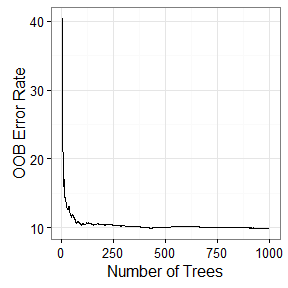

**Figure 2** Random forest generalization error. OOB error convergence along the number of trees in the forest.

```r
> # Plot the OOB errors against the growth of the forest.
> gg_e <- gg_error(rf_Boston)
> plot(gg_e)
```

This figure demonstrates that it does not take a large number of trees to stabilize the forest prediction error estimate. However, to ensure that each variable has enough of a chance to be included in the forest prediction process, we do want to create a rather large random forest of trees.

# Random Forest Prediction

The `gg_rfsrc` function extracts the OOB prediction estimates from the random forest. This code block executes the the data extraction and plotting in one line, since we are not interested in holding the prediction estimates for later reuse. Also note that we add in the additional **ggplot2** command (`coord_cartesian`) to modify the plot object. Each of the **ggRandomForests** plot commands return `ggplot` objects, which we can also store for modification or reuse later in the analysis.

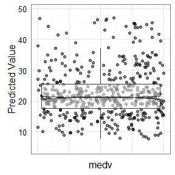

**Figure 3** OOB predicted median home values. Points are jittered to help visualize predictions for each observation. Boxplot indicates the distribution of the predicted values.

```r
> # Plot predicted median home values.
> plot(gg_rfsrc(rf_Boston), alpha=.5)+
+   coord_cartesian(ylim=c(5,49))
```

The `gg_rfsrc` plot shows the predicted median home value, one point for each observation in the training set. The points are jittered around a single point on the x-axis, since we are only looking at predicted values from the forest. These estimates are Out of Bag, which are analogous to test set estimates. The boxplot is shown to give an indication of the distribution of the prediction estimates. For this analysis the figure is another model sanity check, as we are more interested in exploring the “why” questions for these predictions.

# Variable Importance

Random forests are not parsimonious, but use all variables available in the construction of a response predictor. Also, unlike parametric models, Random Forests do not require the explicit specification of the functional form of covariates to the response. Therefore there is no explicit p-value/significance test for variable selection with a random forest model. Instead, RF ascertain which variables contribute to the prediction through the split rule optimization, optimally choosing variables which separate observations.

*Variable importance* (VIMP) was originally defined in CART using a measure involving surrogate variables (see Chapter 5 of (Breiman et al. 1984)). The most popular VIMP method uses a prediction error approach involving “noising-up”" each variable in turn. VIMP for a variable $x_v$ is the difference between prediction error when $x_v$ is noised up by randomly permuting its values, compared to prediction error under the observed values (Breiman 2001, Liaw and Wiener (2002), Ishwaran (2007), Ishwaran et al. (2008)).

Since VIMP is the difference between OOB prediction error before and after permutation, a large VIMP value indicates that misspecification detracts from the variable predictive accuracy in the forest. VIMP close to zero indicates the variable contributes nothing to predictive accuracy, and negative values indicate the predictive accuracy *improves* when the variable is mispecified. In the later case, we assume noise is more informative than the true variable. As such, we ignore variables with negative and near zero values of VIMP, relying on large positive values to indicate that the predictive power of the forest is dependent on those variables.

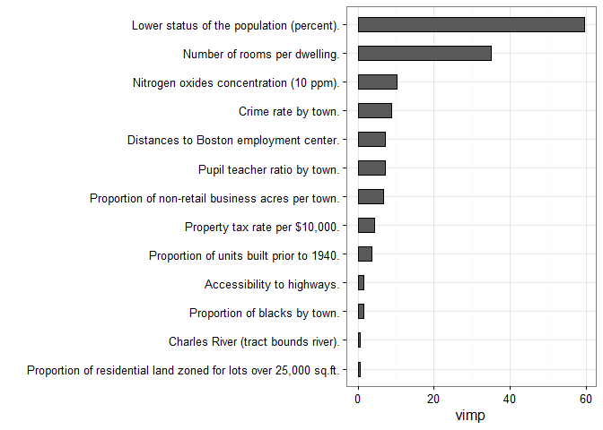

```r
> # Plot the VIMP rankings of independent variables.
> gg_dta <- gg_vimp(rf_Boston)
> plot(gg_dta, lbls=st.labs)
```

For our random forest, the top two variables (`lstat` and `rm`) have the largest VIMP, with a sizable difference to the remaining variables, which mostly have similar VIMP measure. This indicates we should focus attention on these two variables, at least, over the others.

In this example, all VIMP measures are positive, though some are small. When there are both negative and positive VIMP values, the `plot.gg_vimp` function will color VIMP by the sign of the measure. We use the `lbls` argument to pass a named `vector` of meaningful text descriptions to the `plot.gg_vimp` function, replacing the often terse variable names used by default.

# Response/Variable Dependence.

As random forests are not a parsimonious methodology, we can use the minimal depth and VIMP measures to reduce the number of variables we need to examine to a manageable subset. We would like to know how the forest response depends on some specific variables of interest. We often choose to examine variables of interest based on the study question, or other previous knowledge. In the absence of this, we will look at variables that contribute most to the predictive accuracy of the forest.

Although often characterized as a *black box* method, it is possible to express a random forest in functional form. In the end the forest predictor is some function, although complex, of the predictor variables
$$\hat{f}_{rf} = f(x).$$
We use graphical methods to examine the forest predicted response dependency on covariates. We again have two options, variable dependence plots are quick and easy to generate, and partial dependence plots are computationally intensive but give us a risk adjusted look at the dependence.

## Variable Dependence

Variable dependence plots show the predicted response as a function of a covariate of interest, where each observation is represented by a point on the plot. Each predicted point is an individual observations, dependent on the full combination of all other covariates, not only on the covariate of interest. Interpretation of variable dependence plots can only be in general terms, as point predictions are a function of all covariates in that particular observation. However, variable dependence is straight forward to calculate, only requiring the predicted response for each observation.

We use the `gg_variable` function call to extract the training set variables and the predicted OOB response from `randomForest` and `randomForest::predict` objects. In the following code block, we will store the `gg_variable` data object for later use, as all remaining variable dependence plots can be constructed from this (`gg_v`) object. We will also use the VIMP selected variables (VIMP higher than the threshold value) from the previously stored `gg_vimp` object to filter the variables of interest.

The `plot.gg_variable` function call operates in the `gg_variable` object. We pass it the list of variables of interest (`xvar`) and request a single panel (`panel=TRUE`) to display the figures. By default, the `plot.gg_variable` function returns a list of `ggplot` objects, one figure for each variable named in `xvar` argument. The `alpha` argument lightens the coloring points within the `ggplot2::geom_point` call used by the `plot.gg_variable` function, making it easier to see point over plotting. We also demonstrate modification of the plot labels using the `ggplot2::labs` function.

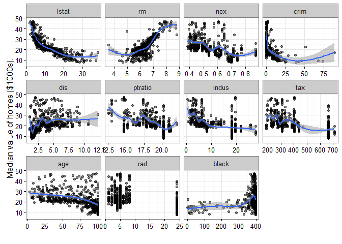

**Figure 5** Variable dependence plot. Individual case predictions are marked with points. Loess smooth curve indicates the trend as the variables increase with shaded 95% confidence band.

```r
> # Create the variable dependence object from the random forest
> gg_v <- gg_variable(rf_Boston)
>
> # We want the top ranked minimal depth variables only,
> # plotted in minimal depth rank order.
> xvar <- gg_dta$vars[gg_dta$vimp>1]
>
> # plot the variable list in a single panel plot
> plot(gg_v, xvar=xvar, panel=TRUE, alpha=.5)+
+   labs(y=st.labs["medv"], x="")
```

This figure looks very similar to the EDA figure, although with transposed axis as we plot the response variable on the y-axis. The closer the panels match, the better the RF prediction. The panels are sorted to match the order of variables in the `xvar` argument and include a smooth loess line (Cleveland 1981, Cleveland and Devlin (1988)), with 95% shaded confidence band, to indicates the trend of the prediction dependence over the covariate values.

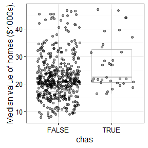

**Figure 6** Variable dependence for Charles River logical variable.

```r
> plot(gg_v, xvar="chas", alpha=.4)+
+   labs(y=st.labs["medv"])
```